# R packages for summarising data - part 2

From: https://dabblingwithdata.wordpress.com/2018/02/26/r-packages-for-summarising-data-part-2/?utm_content=buffer77b34&utm_medium=social&utm_source=twitter.com&utm_campaign=buffer

(part 1: https://dabblingwithdata.wordpress.com/2018/01/02/my-favourite-r-package-for-summarising-data/ )

# R packages for summarising data

```r
library(tidyverse)
library(knitr)
data(mtcars)
```

## Base R

```r
summary(mtcars)
```

```
      mpg             cyl             disp             hp             drat
 Min.   :10.40   Min.   :4.000   Min.   : 71.1   Min.   : 52.0   Min.   :2.760
 1st Qu.:15.43   1st Qu.:4.000   1st Qu.:120.8   1st Qu.: 96.5   1st Qu.:3.080
 Median :19.20   Median :6.000   Median :196.3   Median :123.0   Median :3.695
 Mean   :20.09   Mean   :6.188   Mean   :230.7   Mean   :146.7   Mean   :3.597
 3rd Qu.:22.80   3rd Qu.:8.000   3rd Qu.:326.0   3rd Qu.:180.0   3rd Qu.:3.920
 Max.   :33.90   Max.   :8.000   Max.   :472.0   Max.   :335.0   Max.   :4.930
       wt             qsec             vs               am              gear
 Min.   :1.513   Min.   :14.50   Min.   :0.0000   Min.   :0.0000   Min.   :3.000
 1st Qu.:2.581   1st Qu.:16.89   1st Qu.:0.0000   1st Qu.:0.0000   1st Qu.:3.000
 Median :3.325   Median :17.71   Median :0.0000   Median :0.0000   Median :4.000
 Mean   :3.217   Mean   :17.85   Mean   :0.4375   Mean   :0.4062   Mean   :3.688
 3rd Qu.:3.610   3rd Qu.:18.90   3rd Qu.:1.0000   3rd Qu.:1.0000   3rd Qu.:4.000
 Max.   :5.424   Max.   :22.90   Max.   :1.0000   Max.   :1.0000   Max.   :5.000
      carb
 Min.   :1.000
 1st Qu.:2.000
 Median :2.000
 Mean   :2.812
 3rd Qu.:4.000
 Max.   :8.000
```

```r
by(mtcars, mtcars$cyl, summary)
```

```
mtcars$cyl: 4
      mpg             cyl         disp              hp              drat
 Min.   :21.40   Min.   :4   Min.   : 71.10   Min.   : 52.00   Min.   :3.690
 1st Qu.:22.80   1st Qu.:4   1st Qu.: 78.85   1st Qu.: 65.50   1st Qu.:3.810
 Median :26.00   Median :4   Median :108.00   Median : 91.00   Median :4.080
 Mean   :26.66   Mean   :4   Mean   :105.14   Mean   : 82.64   Mean   :4.071
 3rd Qu.:30.40   3rd Qu.:4   3rd Qu.:120.65   3rd Qu.: 96.00   3rd Qu.:4.165
 Max.   :33.90   Max.   :4   Max.   :146.70   Max.   :113.00   Max.   :4.930
       wt             qsec             vs               am              gear
 Min.   :1.513   Min.   :16.70   Min.   :0.0000   Min.   :0.0000   Min.   :3.000
 1st Qu.:1.885   1st Qu.:18.56   1st Qu.:1.0000   1st Qu.:0.5000   1st Qu.:4.000
 Median :2.200   Median :18.90   Median :1.0000   Median :1.0000   Median :4.000
 Mean   :2.286   Mean   :19.14   Mean   :0.9091   Mean   :0.7273   Mean   :4.091
 3rd Qu.:2.623   3rd Qu.:19.95   3rd Qu.:1.0000   3rd Qu.:1.0000   3rd Qu.:4.000
 Max.   :3.190   Max.   :22.90   Max.   :1.0000   Max.   :1.0000   Max.   :5.000
      carb
 Min.   :1.000
 1st Qu.:1.000
 Median :2.000
 Mean   :1.545
 3rd Qu.:2.000
 Max.   :2.000
--------------------------------------------------------------------
mtcars$cyl: 6
      mpg             cyl         disp             hp             drat
 Min.   :17.80   Min.   :6   Min.   :145.0   Min.   :105.0   Min.   :2.760
 1st Qu.:18.65   1st Qu.:6   1st Qu.:160.0   1st Qu.:110.0   1st Qu.:3.350
 Median :19.70   Median :6   Median :167.6   Median :110.0   Median :3.900
 Mean   :19.74   Mean   :6   Mean   :183.3   Mean   :122.3   Mean   :3.586
 3rd Qu.:21.00   3rd Qu.:6   3rd Qu.:196.3   3rd Qu.:123.0   3rd Qu.:3.910
 Max.   :21.40   Max.   :6   Max.   :258.0   Max.   :175.0   Max.   :3.920
       wt             qsec             vs               am              gear
 Min.   :2.620   Min.   :15.50   Min.   :0.0000   Min.   :0.0000   Min.   :3.000
 1st Qu.:2.822   1st Qu.:16.74   1st Qu.:0.0000   1st Qu.:0.0000   1st Qu.:3.500
 Median :3.215   Median :18.30   Median :1.0000   Median :0.0000   Median :4.000
 Mean   :3.117   Mean   :17.98   Mean   :0.5714   Mean   :0.4286   Mean   :3.857
 3rd Qu.:3.440   3rd Qu.:19.17   3rd Qu.:1.0000   3rd Qu.:1.0000   3rd Qu.:4.000
 Max.   :3.460   Max.   :20.22   Max.   :1.0000   Max.   :1.0000   Max.   :5.000
      carb
 Min.   :1.000
```

[output cut: 13 more lines]

```
 Max.   :19.20   Max.   :8   Max.   :472.0   Max.   :335.0   Max.   :4.220
       wt             qsec             vs          am              gear
 Min.   :3.170   Min.   :14.50   Min.   :0   Min.   :0.0000   Min.   :3.000
 1st Qu.:3.533   1st Qu.:16.10   1st Qu.:0   1st Qu.:0.0000   1st Qu.:3.000
 Median :3.755   Median :17.18   Median :0   Median :0.0000   Median :3.000
 Mean   :3.999   Mean   :16.77   Mean   :0   Mean   :0.1429   Mean   :3.286
 3rd Qu.:4.014   3rd Qu.:17.55   3rd Qu.:0   3rd Qu.:0.0000   3rd Qu.:3.000
 Max.   :5.424   Max.   :18.00   Max.   :0   Max.   :1.0000   Max.   :5.000
      carb
 Min.   :2.00
 1st Qu.:2.25
 Median :3.50
 Mean   :3.50
 3rd Qu.:4.00
 Max.   :8.00
```

## knitr

```r
kable(mtcars)
```

|  | mpg | cyl | disp | hp | drat | wt | qsec | vs | am | gear | carb |
| --- | --- | --- | --- | --- | --- | --- | --- | --- | --- | --- | --- |
| Mazda RX4 | 21.0 | 6 | 160.0 | 110 | 3.90 | 2.620 | 16.46 | 0 | 1 | 4 | 4 |
| Mazda RX4 Wag | 21.0 | 6 | 160.0 | 110 | 3.90 | 2.875 | 17.02 | 0 | 1 | 4 | 4 |
| Datsun 710 | 22.8 | 4 | 108.0 | 93 | 3.85 | 2.320 | 18.61 | 1 | 1 | 4 | 1 |
| Hornet 4 Drive | 21.4 | 6 | 258.0 | 110 | 3.08 | 3.215 | 19.44 | 1 | 0 | 3 | 1 |
| Hornet Sportabout | 18.7 | 8 | 360.0 | 175 | 3.15 | 3.440 | 17.02 | 0 | 0 | 3 | 2 |
| Valiant | 18.1 | 6 | 225.0 | 105 | 2.76 | 3.460 | 20.22 | 1 | 0 | 3 | 1 |
| Duster 360 | 14.3 | 8 | 360.0 | 245 | 3.21 | 3.570 | 15.84 | 0 | 0 | 3 | 4 |
| Merc 240D | 24.4 | 4 | 146.7 | 62 | 3.69 | 3.190 | 20.00 | 1 | 0 | 4 | 2 |
| Merc 230 | 22.8 | 4 | 140.8 | 95 | 3.92 | 3.150 | 22.90 | 1 | 0 | 4 | 2 |
| Merc 280 | 19.2 | 6 | 167.6 | 123 | 3.92 | 3.440 | 18.30 | 1 | 0 | 4 | 4 |
| Merc 280C | 17.8 | 6 | 167.6 | 123 | 3.92 | 3.440 | 18.90 | 1 | 0 | 4 | 4 |
| Merc 450SE | 16.4 | 8 | 275.8 | 180 | 3.07 | 4.070 | 17.40 | 0 | 0 | 3 | 3 |
| Merc 450SL | 17.3 | 8 | 275.8 | 180 | 3.07 | 3.730 | 17.60 | 0 | 0 | 3 | 3 |
| Merc 450SLC | 15.2 | 8 | 275.8 | 180 | 3.07 | 3.780 | 18.00 | 0 | 0 | 3 | 3 |
| Cadillac Fleetwood | 10.4 | 8 | 472.0 | 205 | 2.93 | 5.250 | 17.98 | 0 | 0 | 3 | 4 |
| Lincoln Continental | 10.4 | 8 | 460.0 | 215 | 3.00 | 5.424 | 17.82 | 0 | 0 | 3 | 4 |
| Chrysler Imperial | 14.7 | 8 | 440.0 | 230 | 3.23 | 5.345 | 17.42 | 0 | 0 | 3 | 4 |
| Fiat 128 | 32.4 | 4 | 78.7 | 66 | 4.08 | 2.200 | 19.47 | 1 | 1 | 4 | 1 |
| Honda Civic | 30.4 | 4 | 75.7 | 52 | 4.93 | 1.615 | 18.52 | 1 | 1 | 4 | 2 |
| Toyota Corolla | 33.9 | 4 | 71.1 | 65 | 4.22 | 1.835 | 19.90 | 1 | 1 | 4 | 1 |
| Toyota Corona | 21.5 | 4 | 120.1 | 97 | 3.70 | 2.465 | 20.01 | 1 | 0 | 3 | 1 |
| Dodge Challenger | 15.5 | 8 | 318.0 | 150 | 2.76 | 3.520 | 16.87 | 0 | 0 | 3 | 2 |
| AMC Javelin | 15.2 | 8 | 304.0 | 150 | 3.15 | 3.435 | 17.30 | 0 | 0 | 3 | 2 |
| Camaro Z28 | 13.3 | 8 | 350.0 | 245 | 3.73 | 3.840 | 15.41 | 0 | 0 | 3 | 4 |
| Pontiac Firebird | 19.2 | 8 | 400.0 | 175 | 3.08 | 3.845 | 17.05 | 0 | 0 | 3 | 2 |
| Fiat X1-9 | 27.3 | 4 | 79.0 | 66 | 4.08 | 1.935 | 18.90 | 1 | 1 | 4 | 1 |
| Porsche 914-2 | 26.0 | 4 | 120.3 | 91 | 4.43 | 2.140 | 16.70 | 0 | 1 | 5 | 2 |
| Lotus Europa | 30.4 | 4 | 95.1 | 113 | 3.77 | 1.513 | 16.90 | 1 | 1 | 5 | 2 |
| Ford Pantera L | 15.8 | 8 | 351.0 | 264 | 4.22 | 3.170 | 14.50 | 0 | 1 | 5 | 4 |
| Ferrari Dino | 19.7 | 6 | 145.0 | 175 | 3.62 | 2.770 | 15.50 | 0 | 1 | 5 | 6 |
| Maserati Bora | 15.0 | 8 | 301.0 | 335 | 3.54 | 3.570 | 14.60 | 0 | 1 | 5 | 8 |
| Volvo 142E | 21.4 | 4 | 121.0 | 109 | 4.11 | 2.780 | 18.60 | 1 | 1 | 4 | 2 |

So, can we improve on that effort by using libraries that are not automatically installed as part of base R? I tested 5 options. Inevitably, there are many more possibilities, so please feel free to write in if you think I missed an even better one.

- describe, from the Hmisc package
- stat.desc from pastecs
- describe from psych
- skim from skimr
- descr and dfSummary from summarytools

# Other options

## describe, from the Hmisc package

```r
library(Hmisc)
Hmisc::describe(mtcars)
```

```
mtcars

 11  Variables      32  Observations
-------------------------------------------------------------------------------------------
mpg
       n  missing distinct     Info     Mean      Gmd      .05      .10      .25      .50
      32        0       25    0.999    20.09    6.796    12.00    14.34    15.43    19.20
     .75      .90      .95
   22.80    30.09    31.30

lowest : 10.4 13.3 14.3 14.7 15.0, highest: 26.0 27.3 30.4 32.4 33.9
-------------------------------------------------------------------------------------------
cyl
       n  missing distinct     Info     Mean      Gmd
      32        0        3    0.866    6.188    1.948

Value          4     6     8
Frequency     11     7    14
Proportion 0.344 0.219 0.438
-------------------------------------------------------------------------------------------
disp
       n  missing distinct     Info     Mean      Gmd      .05      .10      .25      .50
      32        0       27    0.999    230.7    142.5    77.35    80.61   120.83   196.30
     .75      .90      .95
  326.00   396.00   449.00

lowest :  71.1  75.7  78.7  79.0  95.1, highest: 360.0 400.0 440.0 460.0 472.0
-------------------------------------------------------------------------------------------
hp
       n  missing distinct     Info     Mean      Gmd      .05      .10      .25      .50
      32        0       22    0.997    146.7    77.04    63.65    66.00    96.50   123.00
     .75      .90      .95
  180.00   243.50   253.55

lowest :  52  62  65  66  91, highest: 215 230 245 264 335
-------------------------------------------------------------------------------------------
drat
       n  missing distinct     Info     Mean      Gmd      .05      .10      .25      .50
      32        0       22    0.997    3.597   0.6099    2.853    3.007    3.080    3.695
     .75      .90      .95
```

[output cut: 31 more lines]

```
       n  missing distinct     Info     Mean      Gmd
      32        0        3    0.841    3.688   0.7863

Value          3     4     5
Frequency     15    12     5
Proportion 0.469 0.375 0.156
-------------------------------------------------------------------------------------------
carb
       n  missing distinct     Info     Mean      Gmd
      32        0        6    0.929    2.812    1.718

Value          1     2     3     4     6     8
Frequency      7    10     3    10     1     1
Proportion 0.219 0.312 0.094 0.312 0.031 0.031
-------------------------------------------------------------------------------------------
```

## stat.desc, from the pastecs package

```r
library(pastecs)
stat.desc(mtcars)
```

|  | mpg | cyl | disp | hp | drat | wt | qsec | vs | am | gear | carb |
| --- | --- | --- | --- | --- | --- | --- | --- | --- | --- | --- | --- |
| nbr.val | 32.0000000 | 32.0000000 | 3.200000e+01 | 32.0000000 | 32.00000000 | 32.0000000 | 32.0000000 | 32.00000000 | 32.00000000 | 32.0000000 | 32.0000000 |
| nbr.null | 0.0000000 | 0.0000000 | 0.000000e+00 | 0.0000000 | 0.00000000 | 0.0000000 | 0.0000000 | 18.00000000 | 19.00000000 | 0.0000000 | 0.0000000 |
| nbr.na | 0.0000000 | 0.0000000 | 0.000000e+00 | 0.0000000 | 0.00000000 | 0.0000000 | 0.0000000 | 0.00000000 | 0.00000000 | 0.0000000 | 0.0000000 |
| min | 10.4000000 | 4.0000000 | 7.110000e+01 | 52.0000000 | 2.76000000 | 1.5130000 | 14.5000000 | 0.00000000 | 0.00000000 | 3.0000000 | 1.0000000 |
| max | 33.9000000 | 8.0000000 | 4.720000e+02 | 335.0000000 | 4.93000000 | 5.4240000 | 22.9000000 | 1.00000000 | 1.00000000 | 5.0000000 | 8.0000000 |
| range | 23.5000000 | 4.0000000 | 4.009000e+02 | 283.0000000 | 2.17000000 | 3.9110000 | 8.4000000 | 1.00000000 | 1.00000000 | 2.0000000 | 7.0000000 |
| sum | 642.9000000 | 198.0000000 | 7.383100e+03 | 4694.0000000 | 115.09000000 | 102.9520000 | 571.1600000 | 14.00000000 | 13.00000000 | 118.0000000 | 90.0000000 |
| median | 19.2000000 | 6.0000000 | 1.963000e+02 | 123.0000000 | 3.69500000 | 3.3250000 | 17.7100000 | 0.00000000 | 0.00000000 | 4.0000000 | 2.0000000 |
| mean | 20.0906250 | 6.1875000 | 2.307219e+02 | 146.6875000 | 3.59656250 | 3.2172500 | 17.8487500 | 0.43750000 | 0.40625000 | 3.6875000 | 2.8125000 |
| SE.mean | 1.0654240 | 0.3157093 | 2.190947e+01 | 12.1203173 | 0.09451874 | 0.1729685 | 0.3158899 | 0.08909831 | 0.08820997 | 0.1304266 | 0.2855297 |

[output cut: 4 more lines]

## describe and describeBy, from the psych package

```r
library(psych)
describe(mtcars)
```

```
     vars  n   mean     sd median trimmed    mad   min    max  range  skew kurtosis    se
mpg     1 32  20.09   6.03  19.20   19.70   5.41 10.40  33.90  23.50  0.61    -0.37  1.07
cyl     2 32   6.19   1.79   6.00    6.23   2.97  4.00   8.00   4.00 -0.17    -1.76  0.32
disp    3 32 230.72 123.94 196.30  222.52 140.48 71.10 472.00 400.90  0.38    -1.21 21.91
hp      4 32 146.69  68.56 123.00  141.19  77.10 52.00 335.00 283.00  0.73    -0.14 12.12
drat    5 32   3.60   0.53   3.70    3.58   0.70  2.76   4.93   2.17  0.27    -0.71  0.09
wt      6 32   3.22   0.98   3.33    3.15   0.77  1.51   5.42   3.91  0.42    -0.02  0.17
qsec    7 32  17.85   1.79  17.71   17.83   1.42 14.50  22.90   8.40  0.37     0.34  0.32
vs      8 32   0.44   0.50   0.00    0.42   0.00  0.00   1.00   1.00  0.24    -2.00  0.09
am      9 32   0.41   0.50   0.00    0.38   0.00  0.00   1.00   1.00  0.36    -1.92  0.09
gear   10 32   3.69   0.74   4.00    3.62   1.48  3.00   5.00   2.00  0.53    -1.07  0.13
carb   11 32   2.81   1.62   2.00    2.65   1.48  1.00   8.00   7.00  1.05     1.26  0.29
```

```r
describeBy(mtcars, as.factor(mtcars$cyl))
```

```
 Descriptive statistics by group
group: 4
     vars  n   mean    sd median trimmed   mad   min    max range  skew kurtosis   se
mpg     1 11  26.66  4.51  26.00   26.44  6.52 21.40  33.90 12.50  0.26    -1.65 1.36
cyl     2 11   4.00  0.00   4.00    4.00  0.00  4.00   4.00  0.00   NaN      NaN 0.00
disp    3 11 105.14 26.87 108.00  104.30 43.00 71.10 146.70 75.60  0.12    -1.64 8.10
hp      4 11  82.64 20.93  91.00   82.67 32.62 52.00 113.00 61.00  0.01    -1.71 6.31
drat    5 11   4.07  0.37   4.08    4.02  0.34  3.69   4.93  1.24  1.00     0.12 0.11
wt      6 11   2.29  0.57   2.20    2.27  0.54  1.51   3.19  1.68  0.30    -1.36 0.17
qsec    7 11  19.14  1.68  18.90   18.99  1.48 16.70  22.90  6.20  0.55    -0.02 0.51
vs      8 11   0.91  0.30   1.00    1.00  0.00  0.00   1.00  1.00 -2.47     4.52 0.09
am      9 11   0.73  0.47   1.00    0.78  0.00  0.00   1.00  1.00 -0.88    -1.31 0.14
gear   10 11   4.09  0.54   4.00    4.11  0.00  3.00   5.00  2.00  0.11    -0.01 0.16
carb   11 11   1.55  0.52   2.00    1.56  0.00  1.00   2.00  1.00 -0.16    -2.15 0.16
--------------------------------------------------------------------
group: 6
     vars n   mean    sd median trimmed   mad    min    max  range  skew kurtosis    se
mpg     1 7  19.74  1.45  19.70   19.74  1.93  17.80  21.40   3.60 -0.16    -1.91  0.55
cyl     2 7   6.00  0.00   6.00    6.00  0.00   6.00   6.00   0.00   NaN      NaN  0.00
disp    3 7 183.31 41.56 167.60  183.31 11.27 145.00 258.00 113.00  0.80    -1.23 15.71
hp      4 7 122.29 24.26 110.00  122.29  7.41 105.00 175.00  70.00  1.36     0.25  9.17
drat    5 7   3.59  0.48   3.90    3.59  0.03   2.76   3.92   1.16 -0.74    -1.40  0.18
wt      6 7   3.12  0.36   3.21    3.12  0.36   2.62   3.46   0.84 -0.22    -1.98  0.13
qsec    7 7  17.98  1.71  18.30   17.98  1.90  15.50  20.22   4.72 -0.12    -1.75  0.65
vs      8 7   0.57  0.53   1.00    0.57  0.00   0.00   1.00   1.00 -0.23    -2.20  0.20
am      9 7   0.43  0.53   0.00    0.43  0.00   0.00   1.00   1.00  0.23    -2.20  0.20
gear   10 7   3.86  0.69   4.00    3.86  0.00   3.00   5.00   2.00  0.11    -1.24  0.26
carb   11 7   3.43  1.81   4.00    3.43  0.00   1.00   6.00   5.00 -0.26    -1.50  0.69
--------------------------------------------------------------------
group: 8
     vars  n   mean    sd median trimmed   mad    min    max  range  skew kurtosis    se
mpg     1 14  15.10  2.56  15.20   15.15  1.56  10.40  19.20   8.80 -0.36    -0.57  0.68
cyl     2 14   8.00  0.00   8.00    8.00  0.00   8.00   8.00   0.00   NaN      NaN  0.00
disp    3 14 353.10 67.77 350.50  349.63 73.39 275.80 472.00 196.20  0.45    -1.26 18.11
hp      4 14 209.21 50.98 192.50  203.67 44.48 150.00 335.00 185.00  0.91     0.09 13.62
drat    5 14   3.23  0.37   3.12    3.19  0.16   2.76   4.22   1.46  1.34     1.08  0.10
wt      6 14   4.00  0.76   3.75    3.95  0.41   3.17   5.42   2.25  0.99    -0.71  0.20
qsec    7 14  16.77  1.20  17.18   16.86  0.79  14.50  18.00   3.50 -0.80    -0.92  0.32
vs      8 14   0.00  0.00   0.00    0.00  0.00   0.00   0.00   0.00   NaN      NaN  0.00
am      9 14   0.14  0.36   0.00    0.08  0.00   0.00   1.00   1.00  1.83     1.45  0.10
gear   10 14   3.29  0.73   3.00    3.17  0.00   3.00   5.00   2.00  1.83     1.45  0.19
carb   11 14   3.50  1.56   3.50    3.25  0.74   2.00   8.00   6.00  1.48     2.24  0.42
```

```r
describeBy(mtcars, mtcars$cyl, mat = TRUE)
```

|  | item | group1 | vars | n | mean | sd | median | trimmed | mad | min | max | range | skew | kurtosis | se |
| --- | --- | --- | --- | --- | --- | --- | --- | --- | --- | --- | --- | --- | --- | --- | --- |
| mpg1 | 1 | 4 | 1 | 11 | 26.6636364 | 4.5098277 | 26.000 | 26.44444444 | 6.523440 | 21.400 | 33.900 | 12.500 | 0.259196493 | -1.64501191 | 1.35976420 |
| mpg2 | 2 | 6 | 1 | 7 | 19.7428571 | 1.4535670 | 19.700 | 19.74285714 | 1.927380 | 17.800 | 21.400 | 3.600 | -0.158313740 | -1.90697145 | 0.54939670 |
| mpg3 | 3 | 8 | 1 | 14 | 15.1000000 | 2.5600481 | 15.200 | 15.15000000 | 1.556730 | 10.400 | 19.200 | 8.800 | -0.362818576 | -0.56551542 | 0.68420163 |
| cyl1 | 4 | 4 | 2 | 11 | 4.0000000 | 0.0000000 | 4.000 | 4.00000000 | 0.000000 | 4.000 | 4.000 | 0.000 | NaN | NaN | 0.00000000 |
| cyl2 | 5 | 6 | 2 | 7 | 6.0000000 | 0.0000000 | 6.000 | 6.00000000 | 0.000000 | 6.000 | 6.000 | 0.000 | NaN | NaN | 0.00000000 |
| cyl3 | 6 | 8 | 2 | 14 | 8.0000000 | 0.0000000 | 8.000 | 8.00000000 | 0.000000 | 8.000 | 8.000 | 0.000 | NaN | NaN | 0.00000000 |
| disp1 | 7 | 4 | 3 | 11 | 105.1363636 | 26.8715937 | 108.000 | 104.30000000 | 42.995400 | 71.100 | 146.700 | 75.600 | 0.120588448 | -1.63539488 | 8.10209033 |
| disp2 | 8 | 6 | 3 | 7 | 183.3142857 | 41.5624602 | 167.600 | 183.31428571 | 11.267760 | 145.000 | 258.000 | 113.000 | 0.795262526 | -1.22862381 | 15.70913335 |
| disp3 | 9 | 8 | 3 | 14 | 353.1000000 | 67.7713236 | 350.500 | 349.63333333 | 73.388700 | 275.800 | 472.000 | 196.200 | 0.452944533 | -1.25914832 | 18.11264812 |
| hp1 | 10 | 4 | 4 | 11 | 82.6363636 | 20.9345300 | 91.000 | 82.66666667 | 32.617200 | 52.000 | 113.000 | 61.000 | 0.006257235 | -1.70893319 | 6.31199828 |

[output cut: 23 more lines]

## skim, from the skimr package

```r
library(skimr)
skim(mtcars)
```

```
Skim summary statistics
 n obs: 32
 n variables: 11

Variable type: numeric
 variable missing complete  n   mean     sd    p0    p25 median    p75   p100
       am       0       32 32   0.41   0.5   0      0      0      1      1
     carb       0       32 32   2.81   1.62  1      2      2      4      8
      cyl       0       32 32   6.19   1.79  4      4      6      8      8
     disp       0       32 32 230.72 123.94 71.1  120.83 196.3  326    472
     drat       0       32 32   3.6    0.53  2.76   3.08   3.7    3.92   4.93
     gear       0       32 32   3.69   0.74  3      3      4      4      5
       hp       0       32 32 146.69  68.56 52     96.5  123    180    335
      mpg       0       32 32  20.09   6.03 10.4   15.43  19.2   22.8   33.9
     qsec       0       32 32  17.85   1.79 14.5   16.89  17.71  18.9   22.9
       vs       0       32 32   0.44   0.5   0      0      0      1      1
       wt       0       32 32   3.22   0.98  1.51   2.58   3.33   3.61   5.42
     hist
 ▇▁▁▁▁▁▁▆
 ▆▇▂▇▁▁▁▁
 ▆▁▁▃▁▁▁▇
 ▇▆▁▂▅▃▁▂
 ▃▇▁▅▇▂▁▁
 ▇▁▁▆▁▁▁▂
 ▃▇▃▅▂▃▁▁
 ▃▇▇▇▃▂▂▂
 ▃▂▇▆▃▃▁▁
 ▇▁▁▁▁▁▁▆
 ▃▃▃▇▆▁▁▂
```

```r
library(dplyr)
library(skimr)
mtcars %>%
  group_by(cyl) %>%
  skim()
```

```
Skim summary statistics
 n obs: 32
 n variables: 11
 group variables: cyl

Variable type: numeric
 cyl variable missing complete  n   mean    sd     p0    p25 median    p75   p100
   4       am       0       11 11   0.73  0.47   0      0.5    1      1      1
   4     carb       0       11 11   1.55  0.52   1      1      2      2      2
   4     disp       0       11 11 105.14 26.87  71.1   78.85 108    120.65 146.7
   4     drat       0       11 11   4.07  0.37   3.69   3.81   4.08   4.17   4.93
   4     gear       0       11 11   4.09  0.54   3      4      4      4      5
   4       hp       0       11 11  82.64 20.93  52     65.5   91     96    113
   4      mpg       0       11 11  26.66  4.51  21.4   22.8   26     30.4   33.9
   4     qsec       0       11 11  19.14  1.68  16.7   18.56  18.9   19.95  22.9
   4       vs       0       11 11   0.91  0.3    0      1      1      1      1
   4       wt       0       11 11   2.29  0.57   1.51   1.89   2.2    2.62   3.19
   6       am       0        7  7   0.43  0.53   0      0      0      1      1
   6     carb       0        7  7   3.43  1.81   1      2.5    4      4      6
   6     disp       0        7  7 183.31 41.56 145    160    167.6  196.3  258
   6     drat       0        7  7   3.59  0.48   2.76   3.35   3.9    3.91   3.92
   6     gear       0        7  7   3.86  0.69   3      3.5    4      4      5
   6       hp       0        7  7 122.29 24.26 105    110    110    123    175
   6      mpg       0        7  7  19.74  1.45  17.8   18.65  19.7   21     21.4
   6     qsec       0        7  7  17.98  1.71  15.5   16.74  18.3   19.17  20.22
   6       vs       0        7  7   0.57  0.53   0      0      1      1      1
   6       wt       0        7  7   3.12  0.36   2.62   2.82   3.21   3.44   3.46
   8       am       0       14 14   0.14  0.36   0      0      0      0      1
   8     carb       0       14 14   3.5   1.56   2      2.25   3.5    4      8
   8     disp       0       14 14 353.1  67.77 275.8  301.75 350.5  390    472
   8     drat       0       14 14   3.23  0.37   2.76   3.07   3.12   3.22   4.22
   8     gear       0       14 14   3.29  0.73   3      3      3      3      5
   8       hp       0       14 14 209.21 50.98 150    176.25 192.5  241.25 335
   8      mpg       0       14 14  15.1   2.56  10.4   14.4   15.2   16.25  19.2
   8     qsec       0       14 14  16.77  1.2   14.5   16.1   17.18  17.55  18
   8       vs       0       14 14   0     0      0      0      0      0      0
   8       wt       0       14 14   4     0.76   3.17   3.53   3.75   4.01   5.42
     hist
 ▃▁▁▁▁▁▁▇
 ▇▁▁▁▁▁▁▇
```

[output cut: 13 more lines]

```
 ▇▁▃▁▁▁▁▂
 ▅▁▁▂▂▁▁▇
 ▇▇▇▁▇▇▇▇
 ▆▁▁▁▁▁▁▇
 ▂▂▂▁▁▂▁▇
 ▇▁▁▁▁▁▁▁
 ▅▃▇▁▁▁▁▁
 ▆▆▁▇▁▂▂▃
 ▃▇▆▁▂▂▁▂
 ▇▁▁▁▁▁▁▁
 ▃▇▃▂▅▁▁▂
 ▃▁▂▃▇▂▂▃
 ▃▁▂▂▁▆▆▇
 ▁▁▁▇▁▁▁▁
 ▆▇▆▂▁▁▁▆
```

## descr and dfSummary, from the summarytools package

```r
library(summarytools)
summarytools::descr(mtcars)
```

```
Descriptive Statistics
Data Frame: mtcars
N: 32

                       mpg      cyl     disp       hp     drat       wt     qsec
----------------- -------- -------- -------- -------- -------- -------- --------
             Mean    20.09     6.19   230.72   146.69     3.60     3.22    17.85
          Std.Dev     6.03     1.79   123.94    68.56     0.53     0.98     1.79
              Min    10.40     4.00    71.10    52.00     2.76     1.51    14.50
           Median    19.20     6.00   196.30   123.00     3.70     3.33    17.71
              Max    33.90     8.00   472.00   335.00     4.93     5.42    22.90
              MAD     5.41     2.97   140.48    77.10     0.70     0.77     1.42
              IQR     7.38     4.00   205.18    83.50     0.84     1.03     2.01
               CV     3.33     3.46     1.86     2.14     6.73     3.29     9.99
         Skewness     0.61    -0.17     0.38     0.73     0.27     0.42     0.37
      SE.Skewness     0.41     0.41     0.41     0.41     0.41     0.41     0.41
         Kurtosis    -0.37    -1.76    -1.21    -0.14    -0.71    -0.02     0.34
          N.Valid    32.00    32.00    32.00    32.00    32.00    32.00    32.00
        Pct.Valid   100.00   100.00   100.00   100.00   100.00   100.00   100.00

Table: Table continues below



                        vs       am     gear     carb
----------------- -------- -------- -------- --------
             Mean     0.44     0.41     3.69     2.81
          Std.Dev     0.50     0.50     0.74     1.62
              Min     0.00     0.00     3.00     1.00
           Median     0.00     0.00     4.00     2.00
              Max     1.00     1.00     5.00     8.00
              MAD     0.00     0.00     1.48     1.48
              IQR     1.00     1.00     1.00     2.00
               CV     0.87     0.81     5.00     1.74
         Skewness     0.24     0.36     0.53     1.05
      SE.Skewness     0.41     0.41     0.41     0.41
         Kurtosis    -2.00    -1.92    -1.07     1.26
          N.Valid    32.00    32.00    32.00    32.00
        Pct.Valid   100.00   100.00   100.00   100.00
```

```r
dfSummary(mtcars)
```

```
Data Frame Summary
mtcars
N: 32
--------------------------------------------------------------------------------------------------------------
No   Variable    Stats / Values                  Freqs (% of Valid)   Text Graph            Valid    Missing
---- ----------- ------------------------------- -------------------- --------------------- -------- ---------
1    mpg         mean (sd) : 20.09 (6.03)        25 distinct val.       :                   32       0
     [numeric]   min < med < max :                                      :                   (100%)   (0%)
                 10.4 < 19.2 < 33.9                                     : :
                 IQR (CV) : 7.38 (0.3)                                : : :
                                                                      : : :   :
                                                                      : : : : :

2    cyl         mean (sd) : 6.19 (1.79)         4 : 11 (34.4%)       IIIIIIIIIIII          32       0
     [numeric]   min < med < max :               6 :  7 (21.9%)       IIIIIIII              (100%)   (0%)
                 4 < 6 < 8                       8 : 14 (43.8%)       IIIIIIIIIIIIIIII
                 IQR (CV) : 4 (0.29)

3    disp        mean (sd) : 230.72 (123.94)     27 distinct val.       :                   32       0
     [numeric]   min < med < max :                                      :   .               (100%)   (0%)
                 71.1 < 196.3 < 472                                     :   :
                 IQR (CV) : 205.18 (0.54)                             . : . :
                                                                      : : : : .
                                                                      : : : : :

4    hp          mean (sd) : 146.69 (68.56)      22 distinct val.     . :                   32       0
     [numeric]   min < med < max :                                    : :                   (100%)   (0%)
                 52 < 123 < 335                                       : : .
                 IQR (CV) : 83.5 (0.47)                               : : : :
                                                                      : : : :
                                                                      : : : : . .

5    drat        mean (sd) : 3.6 (0.53)          22 distinct val.         :                 32       0
     [numeric]   min < med < max :                                      . :                 (100%)   (0%)
                 2.76 < 3.7 < 4.93                                      : :
                 IQR (CV) : 0.84 (0.15)                                 : : :
                                                                      : : : :
                                                                      : : : : .

6    wt          mean (sd) : 3.22 (0.98)         29 distinct val.           :               32       0
```

[output cut: 20 more lines]

```
                 0 < 0 < 1
                 IQR (CV) : 1 (1.23)

10   gear        mean (sd) : 3.69 (0.74)         3 : 15 (46.9%)       IIIIIIIIIIIIIIII      32       0
     [numeric]   min < med < max :               4 : 12 (37.5%)       IIIIIIIIIIII          (100%)   (0%)
                 3 < 4 < 5                       5 :  5 (15.6%)       IIIII
                 IQR (CV) : 1 (0.2)

11   carb        mean (sd) : 2.81 (1.62)         1 :  7 (21.9%)       IIIIIIIIIII           32       0
     [numeric]   min < med < max :               2 : 10 (31.2%)       IIIIIIIIIIIIIIII      (100%)   (0%)
                 1 < 2 < 8                       3 :  3 ( 9.4%)       IIII
                 IQR (CV) : 2 (0.57)             4 : 10 (31.2%)       IIIIIIIIIIIIIIII
                                                 6 :  1 ( 3.1%)       I
                                                 8 :  1 ( 3.1%)       I
--------------------------------------------------------------------------------------------------------------
```

# R packages for summarising data – part 2

Now then, onto some new packages! I collated the many kind suggestions, and had a look at:

- CreateTableOne, from the tableone package
- desctable from desctable
- ggpairs from GGally
- ds_summary_stats from Descriptr

I was also going to look at the CompareGroups package, but unfortunately it had apparently been removed from CRAN recently because “check problems were not corrected in time” apparently. Maybe I’ll try again in future.

## CreateTableOne, from the tableone package

```r
CreateTableOne(data = mtcars)
```

```
                   Overall
  n                    32
  mpg (mean (sd))   20.09 (6.03)
  cyl (mean (sd))    6.19 (1.79)
  disp (mean (sd)) 230.72 (123.94)
  hp (mean (sd))   146.69 (68.56)
  drat (mean (sd))   3.60 (0.53)
  wt (mean (sd))     3.22 (0.98)
  qsec (mean (sd))  17.85 (1.79)
  vs (mean (sd))     0.44 (0.50)
  am (mean (sd))     0.41 (0.50)
  gear (mean (sd))   3.69 (0.74)
  carb (mean (sd))   2.81 (1.62)
```

```r
CreateTableOne(strata = "cyl", data = mtcars)
```

```
                  Stratified by cyl
                   4              6              8              p      test
  n                    11              7             14
  mpg (mean (sd))   26.66 (4.51)   19.74 (1.45)   15.10 (2.56)  <0.001
  cyl (mean (sd))    4.00 (0.00)    6.00 (0.00)    8.00 (0.00)  <0.001
  disp (mean (sd)) 105.14 (26.87) 183.31 (41.56) 353.10 (67.77) <0.001
  hp (mean (sd))    82.64 (20.93) 122.29 (24.26) 209.21 (50.98) <0.001
  drat (mean (sd))   4.07 (0.37)    3.59 (0.48)    3.23 (0.37)  <0.001
  wt (mean (sd))     2.29 (0.57)    3.12 (0.36)    4.00 (0.76)  <0.001
  qsec (mean (sd))  19.14 (1.68)   17.98 (1.71)   16.77 (1.20)   0.002
  vs (mean (sd))     0.91 (0.30)    0.57 (0.53)    0.00 (0.00)  <0.001
  am (mean (sd))     0.73 (0.47)    0.43 (0.53)    0.14 (0.36)   0.010
  gear (mean (sd))   4.09 (0.54)    3.86 (0.69)    3.29 (0.73)   0.015
  carb (mean (sd))   1.55 (0.52)    3.43 (1.81)    3.50 (1.56)   0.003
```

You might note above that not only do you get the summary segmented by group, but you also automatically get p values from a statistical hypothesis test as to whether the groups differ from each other. By default these are either chi-squared for categorical variables or ANOVA for continuous variables. You can add parameters to use non-parametric or exact tests though if you feel they are more appropriate. This also changes up the summary stats that are shown for numeric variables – which also happens if you apply the nonnormal parameter even without stratification.

## desctable, from the desctable package

```r
library(desctable)
desctable(mtcars)
```

```
         N      Mean        sd     Med       IQR
1   mpg 32 20.090625 6.0269481      NA        NA
2   cyl 32        NA        NA   6.000   4.00000
3  disp 32        NA        NA 196.300 205.17500
4    hp 32        NA        NA 123.000  83.50000
5  drat 32  3.596563 0.5346787      NA        NA
6    wt 32        NA        NA   3.325   1.02875
7  qsec 32 17.848750 1.7869432      NA        NA
8    vs 32        NA        NA   0.000   1.00000
9    am 32        NA        NA   0.000   1.00000
10 gear 32        NA        NA   4.000   1.00000
11 carb 32        NA        NA   2.000   2.00000
```

```r
mtcars %>%
  group_by(cyl) %>%
  desctable()
```

```
        cyl: 4 (n=11) / N cyl: 4 (n=11) / Med cyl: 4 (n=11) / IQR cyl: 6 (n=7) / N1
1   mpg                11               26.00              7.6000                 7
2  disp                11              108.00             41.8000                 7
3    hp                11               91.00             30.5000                 7
4  drat                11                4.08              0.3550                 7
5    wt                11                2.20              0.7375                 7
6  qsec                11               18.90              1.3900                 7
7    vs                11                1.00              0.0000                 7
8    am                11                1.00              0.5000                 7
9  gear                11                4.00              0.0000                 7
10 carb                11                2.00              1.0000                 7
   cyl: 6 (n=7) / Med1 cyl: 6 (n=7) / IQR1 cyl: 8 (n=14) / N2 cyl: 8 (n=14) / Med2
1               19.700              2.3500                 14               15.200
2              167.600             36.3000                 14              350.500
3              110.000             13.0000                 14              192.500
```

[output cut: 18 more lines]

Note also the nice way that it has picked an appropriate statistical test to automatically test for significant differences between groups. Here it picked the Kruskall-Wallis test for the numeric fields as the data was detected as being non-normally distributed.

## ggpairs, from the GGally package

[output not shown]

[output cut: 66 more lines]

[output not shown]

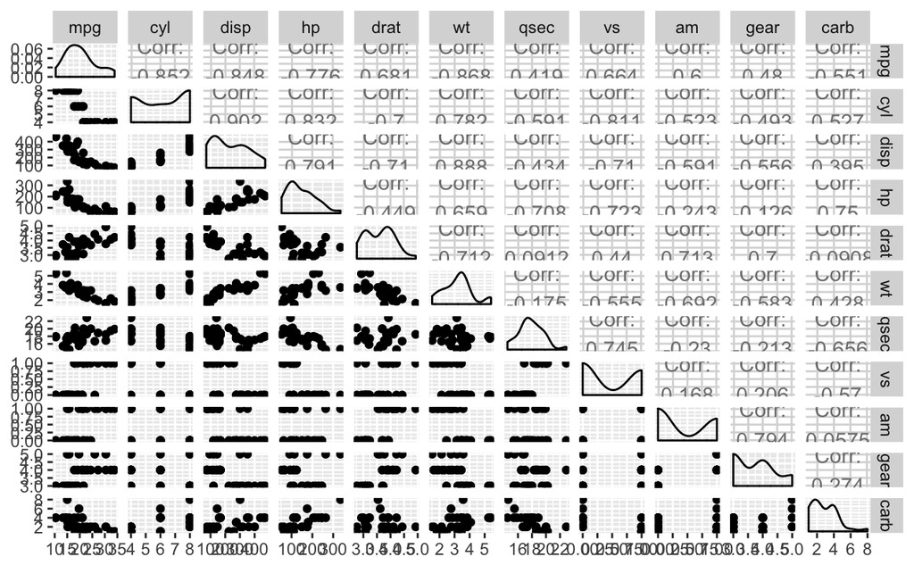

```r
library(GGally)
ggpairs(mtcars)
```

[output not shown]

[output cut: 89 more lines]

[output not shown]

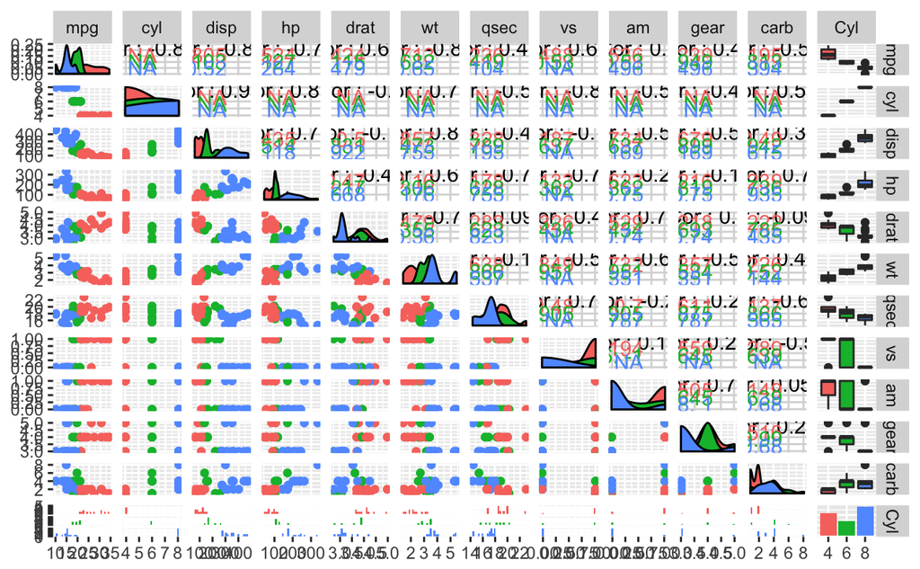

```r
# ggpairs(mtcars, mapping = aes(colour = as.factor(cyl)))
mtcars %>%
  mutate(Cyl = as.factor(cyl)) %>%
  ggpairs(aes(colour = Cyl))
```

## ds_summary_stats from descriptr

```r
ds_summary_stats(mtcars$disp)
```

```
Error in UseMethod("pull") :
  no applicable method for 'pull' applied to an object of class "c('double', 'numeric')"
```

```r
ds_screener(mtcars)
```

```
----------------------------------------------------------------------
|  Column Name  |  Data Type  |  Levels  |  Missing  |  Missing (%)  |
----------------------------------------------------------------------
|      mpg      |   numeric   |    NA    |     0     |       0       |
|      cyl      |   numeric   |    NA    |     0     |       0       |
|     disp      |   numeric   |    NA    |     0     |       0       |
|      hp       |   numeric   |    NA    |     0     |       0       |
|     drat      |   numeric   |    NA    |     0     |       0       |
|      wt       |   numeric   |    NA    |     0     |       0       |
|     qsec      |   numeric   |    NA    |     0     |       0       |
|      vs       |   numeric   |    NA    |     0     |       0       |
|      am       |   numeric   |    NA    |     0     |       0       |
|     gear      |   numeric   |    NA    |     0     |       0       |
|     carb      |   numeric   |    NA    |     0     |       0       |
----------------------------------------------------------------------

 Overall Missing Values           0
 Percentage of Missing Values     0 %
 Rows with Missing Values         0
 Columns With Missing Values      0
```